# Red Wine Quality Exploration by Taghreed

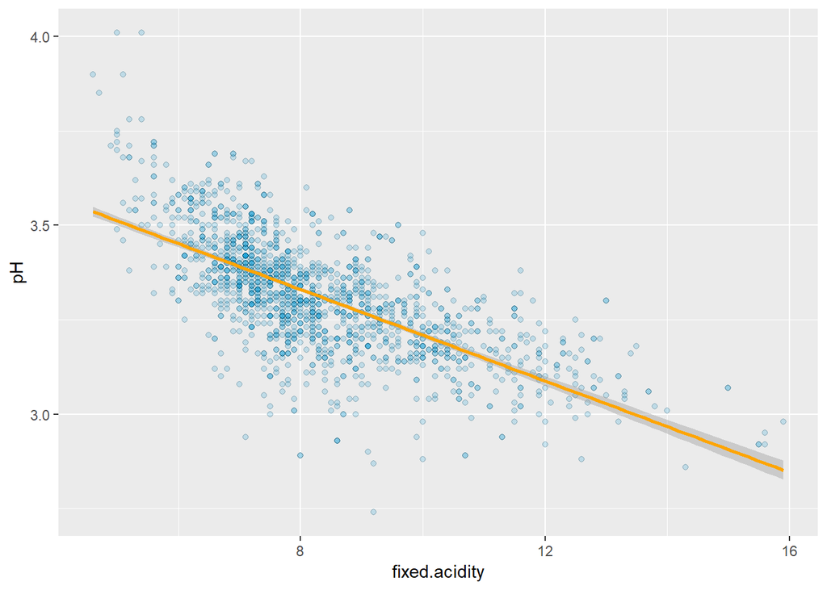

As fixed.acidity increases, the pH decreases.

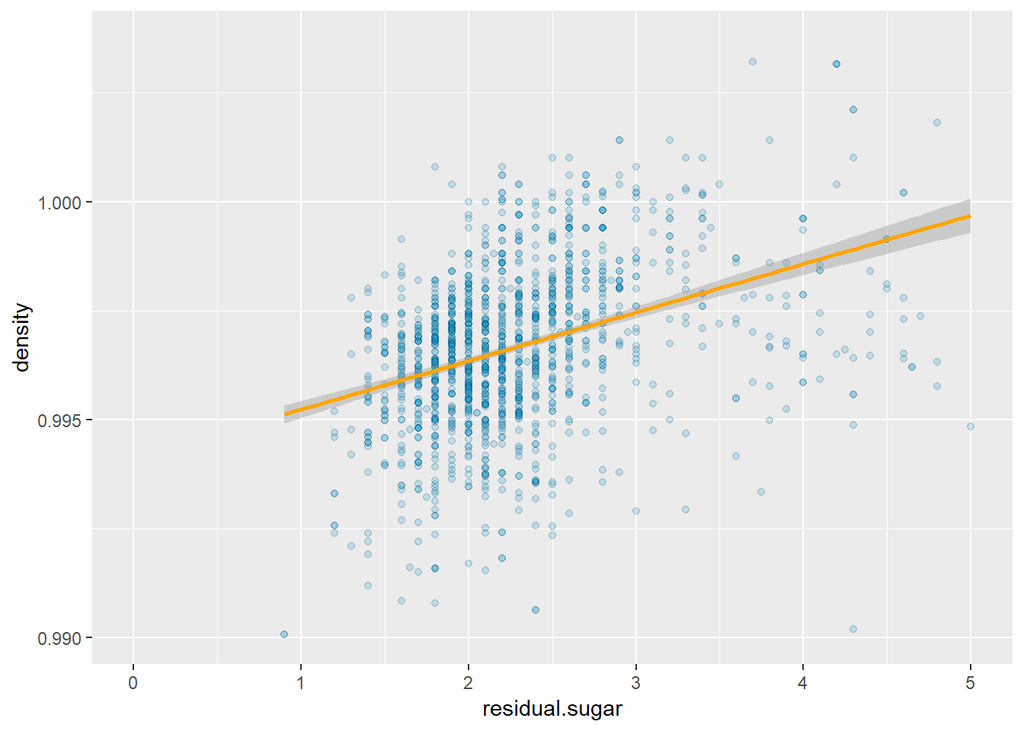

As residual.sugar increases, the density increases and this is clear in range (0-5) of residual.sugar.

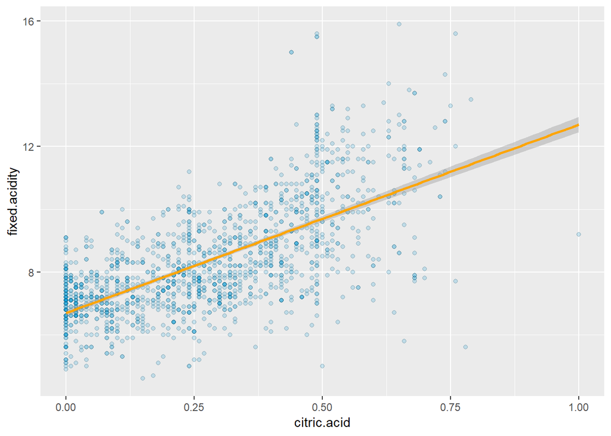

As citric.acid increases, the fixed.acidity increases.

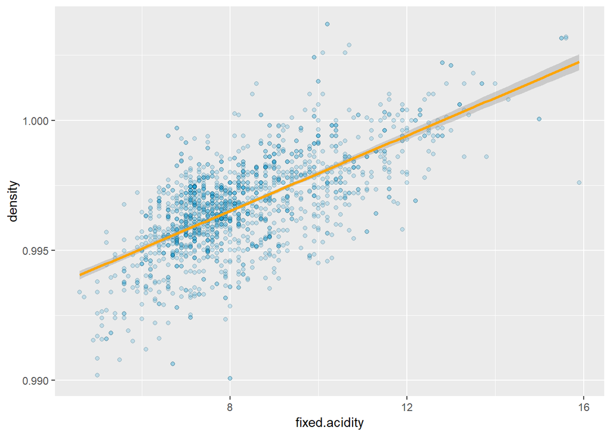

As fixed.acidity increases, the density increases.

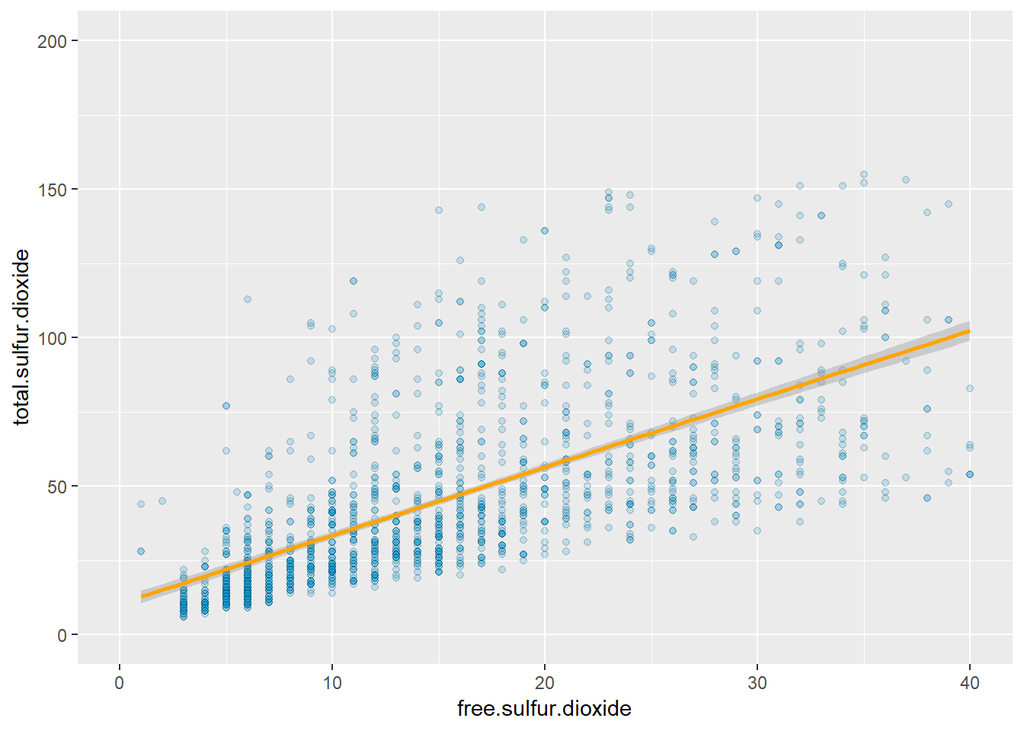

As free.sulfur.dioxide increases, the total.sulfur.dioxide increases.

# Bivariate Analysis

### Talk about some of the relationships you observed in this part of the investigation. How did the feature(s) of interest vary with other features in the dataset?

The quality is postively correlated with alcohol, citric.acid & sulphates. The quality is negatively correlated with volatile.acidity. Other input varibles don’t show much effect on quality.

### Did you observe any interesting relationships between the other features (not the main feature(s) of interest)?

According correlation Matrix

| Variables | Correlation |
| --- | --- |
| residual.sugar ~ density | 0.4 |
| citric.acid ~ fixed.acidity | 0.7 |
| density ~ fixed.acidity | 0.7 |
| free.sulfur.dioxide ~ total.sulfur.dioxide | 0.7 |
| pH ~ fixed.acidity | -0.7 |
| volatile.acidity ~ citric.acid | -0.6 |
| alcohol ~ density | -0.5 |
| pH ~ citric.acid | -0.5 |

Most of these relationships show that some variables are dependeing on each other:

- More acidity leads to low pH
- More alcohol less dense
- More sugar more dense

### What was the strongest relationship you found?

According correlations between variables the strongest relationship is between pH ~ fixed.acidity (negatively). Also (citric.acid ~ fixed.acidity) & (density ~ fixed.acidity) are strong.

Related to the output quality, volatile.acidity is negatively correlated with quality.

# Multivariate Plots Section

Consider wine with quality(7-8) is high quality wine & quality(5-6) which represnt the most of observations in the data is medium quality wine.

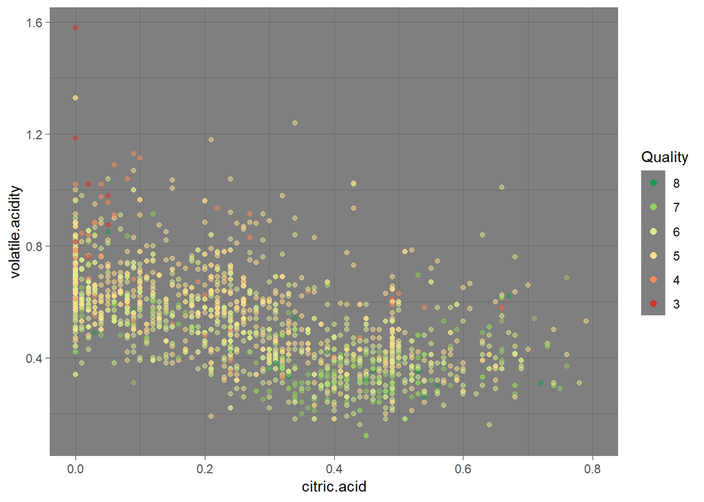

Most of High quality wine seem to have high citric.acid & low volatile.acidity.

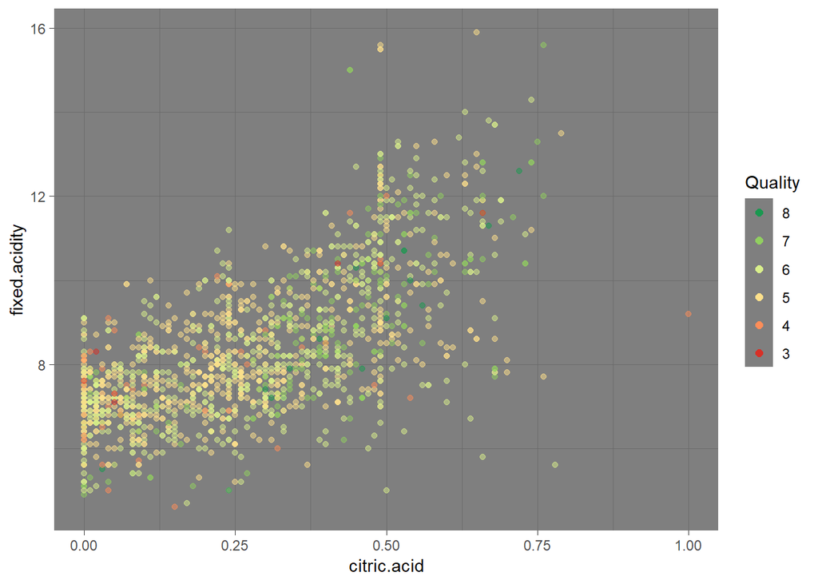

High quality wine seem to have high citric.acid & high fixed.acidity.

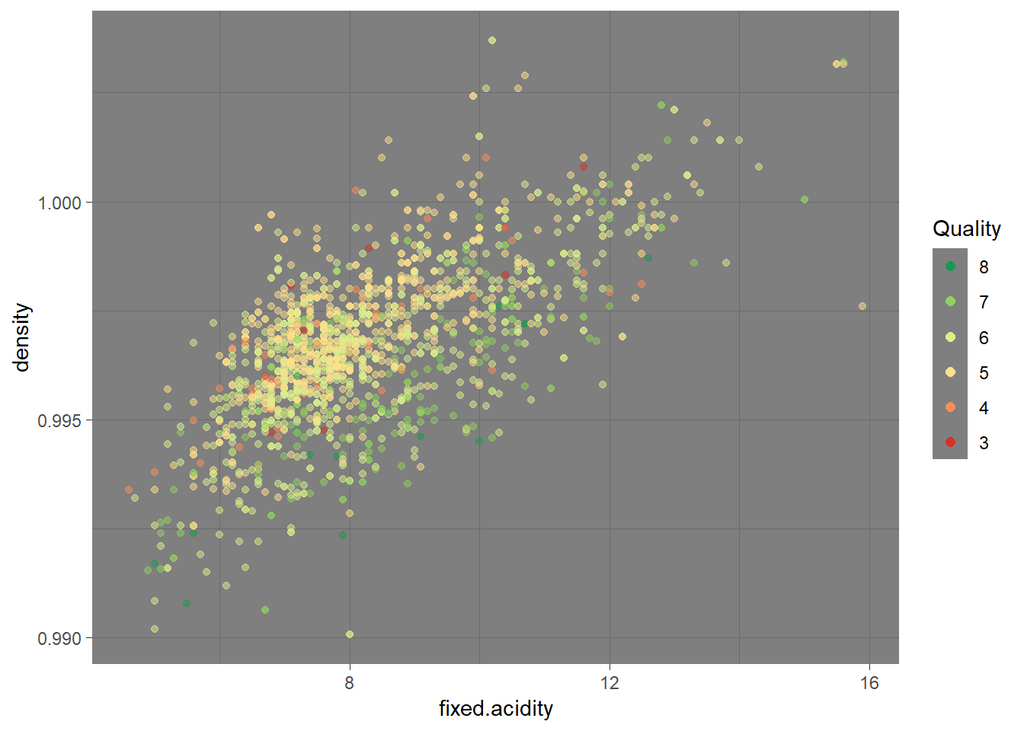

Most of High quality wine seem to have lower density compared to moderate wine quality.

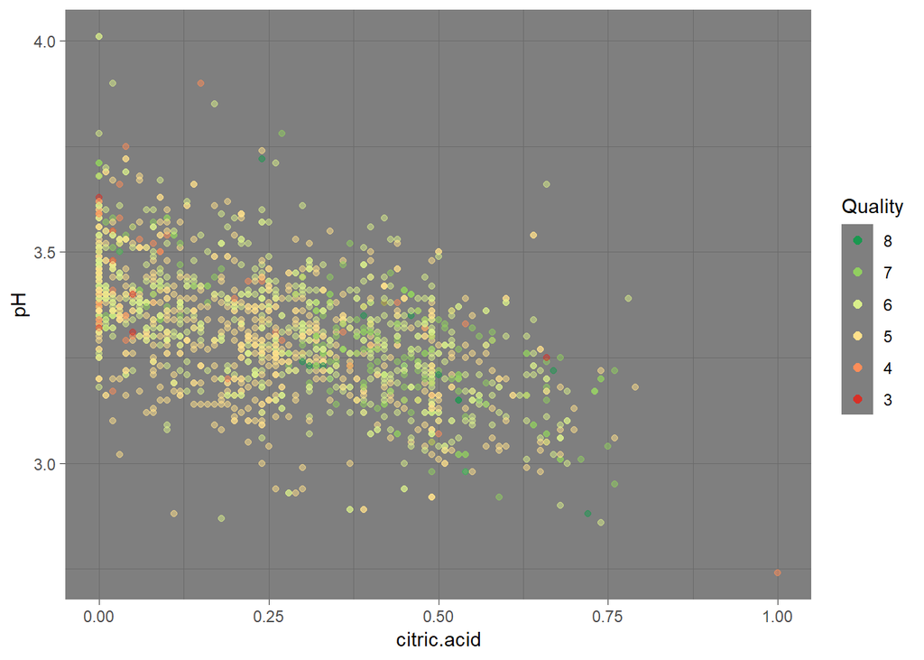

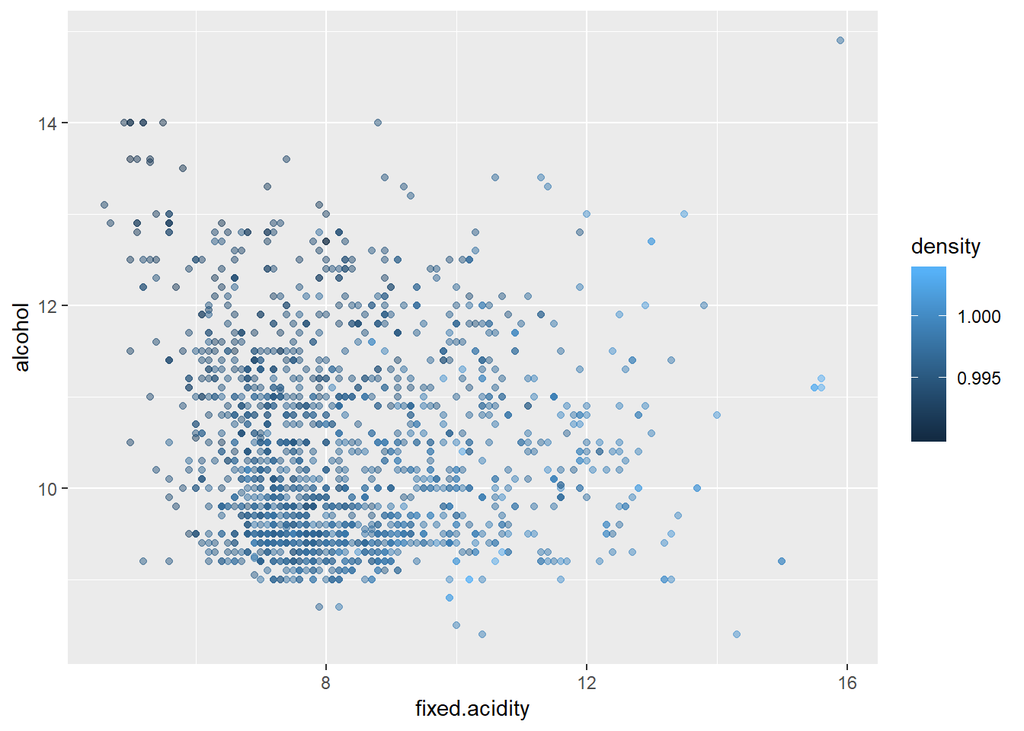

Density seems to be affected by fixed acidity more than alcohol (looking at how color gradient horizontally).

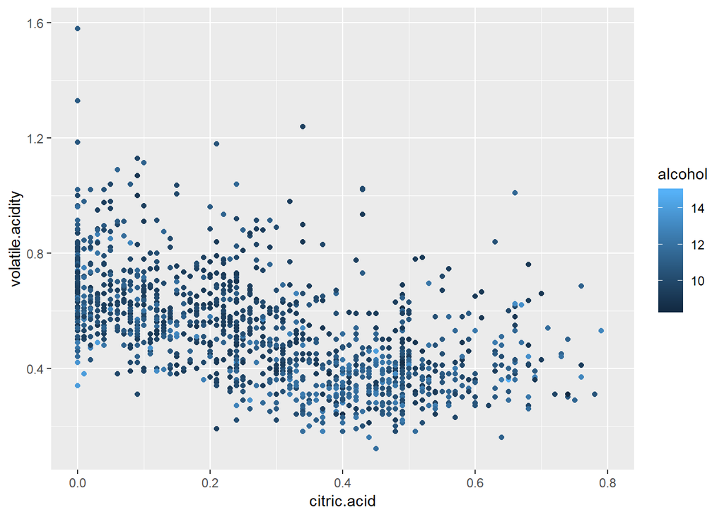

Wine with more alcohol tends to have more citric acid and less volatile acidity.

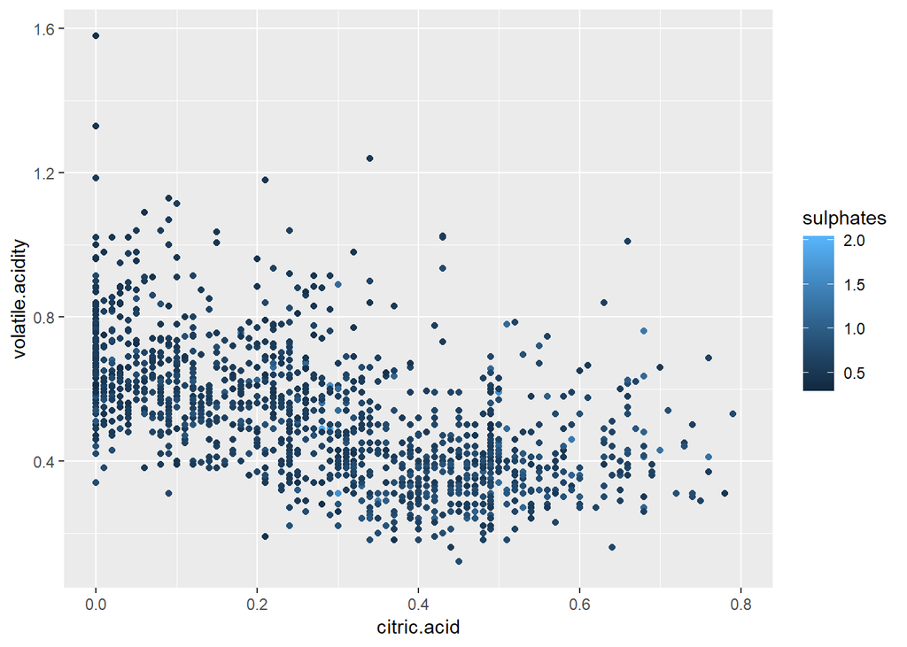

Wine with more sulphates tends to have more citric acid and less volatile acidity.

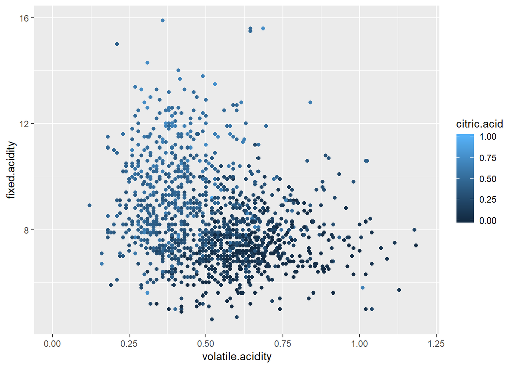

Wine with more volatile acidity tends to have less citric acid and less fixed acidity.

```r
## Creating linear models to predict quality
m1 <- lm(as.numeric(quality) ~ alcohol, data = red)
m2 <- update(m1, ~ . + volatile.acidity)
m3 <- update(m2, ~ . + citric.acid)
m4 <- update(m3, ~ . + log(sulphates))

mtable(m1, m2, m3, m4)
```

```
##
## Calls:
## m1: lm(formula = as.numeric(quality) ~ alcohol, data = red)
## m2: lm(formula = as.numeric(quality) ~ alcohol + volatile.acidity,
##     data = red)
## m3: lm(formula = as.numeric(quality) ~ alcohol + volatile.acidity +
##     citric.acid, data = red)
## m4: lm(formula = as.numeric(quality) ~ alcohol + volatile.acidity +
##     citric.acid + log(sulphates), data = red)
##
## ========================================================================
##                         m1           m2           m3           m4
## ------------------------------------------------------------------------
##   (Intercept)         -0.125        1.095***     1.055***     1.444***
##                       (0.175)      (0.184)      (0.194)      (0.196)
##   alcohol              0.361***     0.314***     0.314***     0.303***
##                       (0.017)      (0.016)      (0.016)      (0.016)
##   volatile.acidity                 -1.384***    -1.343***    -1.217***
##                                    (0.095)      (0.114)      (0.112)
##   citric.acid                                    0.068       -0.113
##                                                 (0.103)      (0.103)
##   log(sulphates)                                              0.659***
##                                                              (0.079)
## ------------------------------------------------------------------------
##   R-squared            0.227        0.317        0.317        0.346
##   N                 1599         1599         1599         1599
## ========================================================================
##   Significance: *** = p < 0.001; ** = p < 0.01; * = p < 0.05
```

# Multivariate Analysis

### Talk about some of the relationships you observed in this part of the investigation. Were there features that strengthened each other in terms of looking at your feature(s) of interest?

I used the correlated variables in Bivariate Analysis & check with quality & other correlated variable.

I can say that high quality wine have high (alcohol, citric acid, sulphates) & low volatile acidity, other variables don’t show any remarkable effect on quality.

### Were there any interesting or surprising interactions between features?

Citric Acid vs Volatile Acidity vs Fixed Acidity.

### OPTIONAL: Did you create any models with your dataset? Discuss the strengths and limitations of your model.

## I create four models using four variables(alcohol, volatile acidity, citric acid, sulphates), the models aren’t accurate, beacuse of the few variables that affect quality. Also the few observations in this data set.

# Final Plots and Summary

### Plot One

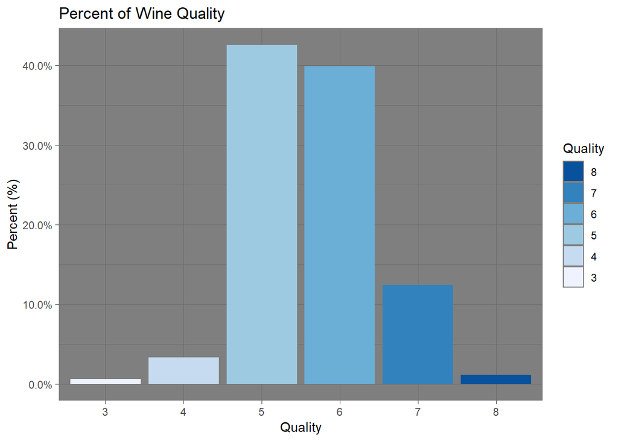

### Description One

In this dataset there is no wine has quality > 8 or < 3. Most of red wine have quality of 5 or 6.

It seems that red wine isn’t favored too much by majority.

### Plot Two

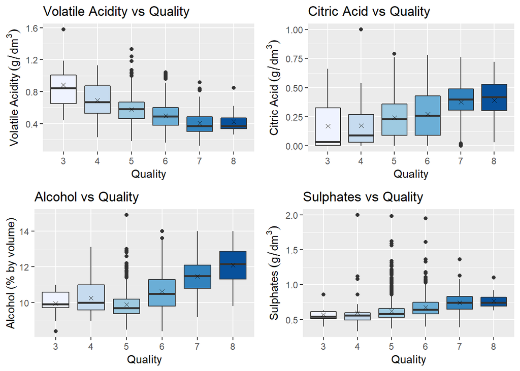

### Description Two

Shows chemicals that have a remarkable effect on red wine. - The quality is postively correlated with alcohol, citric.acid & sulphates. - The quality is negatively correlated with volatile.acidity.

### Plot Three

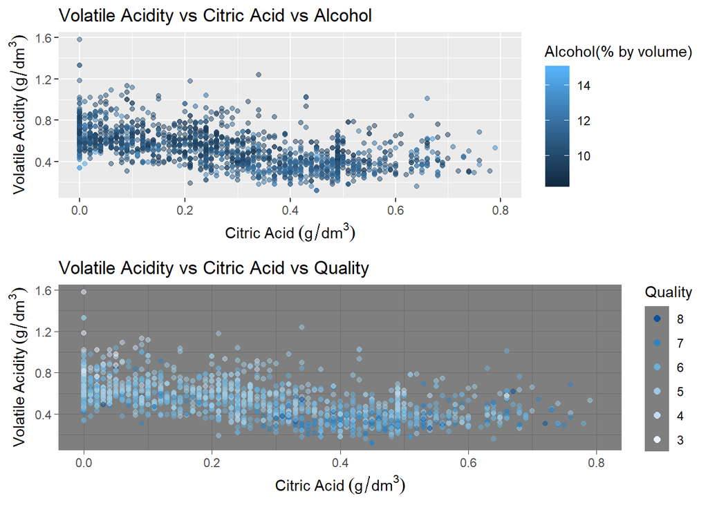

## High quality red wine have high (alcohol, citric acid) & low volatile acidity.

# Reflection

Red Wine dataset has 1599 observations and 12 variables (11 chemical content & quality).

I started with checking the distributions of each variable, then check which variable affect the quality of red wine.

Find the other correlated varibles to find relationships within input variables.

Then combine the correlated varibles with quality & other varibles.

### Insights

- It seems that red wine isn’t favored too much by majority.
- Alcohol, Citric Acid, Sulphates Volatile acidity remarkable effect on quality.
- High quality red wine have high (alcohol, citric acid) & low volatile acidity.

### Struggles

The few variables that affect quality was hard to find, Also the few observations in this data set, It was hard to create an accurate model to predict quality.

### Future Work

Adding more varibles can be helpful, Also combining the red wine data with white wine data & compare between the both may lead to great result.